# Reproducible Research: Peer Assessment 1

### Inputing the missing values

#### 1. Calculate and report the total number of missing values in the dataset (i.e. the total number of rows with NAs).

#### The number of NA is:

```r
# Sum the total NA's
sum_na <- length(which(is.na(activity$steps)))
sum_na
```

```
## [1] 2304
```

#### 3. Create a new dataset that is equal to the original dataset but with the missing data filled in.

```r
activity_new <- activity
activity_new$steps <- impute(activity$steps, fun=mean)
```

#### 4. Make a histogram of the total number of steps taken each day and calculate and report the mean and median total number of steps taken per day. Do these values differ from the estimates from the first part of the assignment? What is the impact of imputing missing data on the estimates of the total daily number of steps?

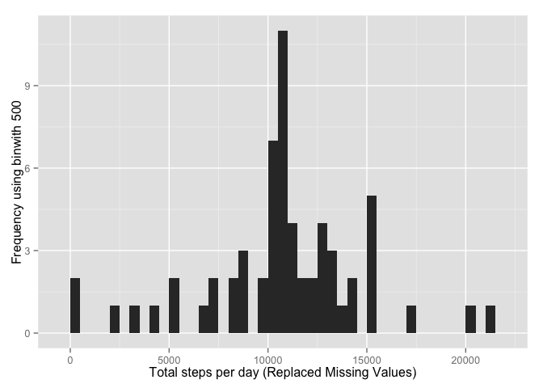

```r
# Make histogram
steps_by_day_new <- tapply(activity_new$steps, activity_new$date, sum)
qplot(steps_by_day_new, xlab='Total steps per day (Replaced Missing Values)', ylab='Frequency using binwith 500', binwidth=500)
```

##### The mean total number of steps taken per day is:

```r
steps_by_day_new_mean <- mean(steps_by_day_new)
steps_by_day_new_mean
```

```
## [1] 10766.19
```

##### The median total number of steps taken per day is:

```r
steps_by_day_new_median <- median(steps_by_day_new)
steps_by_day_new_median
```

```
## [1] 10766.19
```

### Are there differences in activity patterns between weekdays and weekends?

#### 1. Create a new factor variable in the dataset with two levels - weekdays and weekend indicating whether a given date is a weekday or weekend day.

```r
activity_new$dayType <-  ifelse(as.POSIXlt(activity_new$date)$wday %in% c(0,6), 'Weekend', 'Weekday')
```

#### 2. Make a panel plot containing a time series plot (i.e. type = “l”) of the 5- minute interval (x-axis) and the average number of steps taken, averaged across all weekday days or weekend days (y-axis).

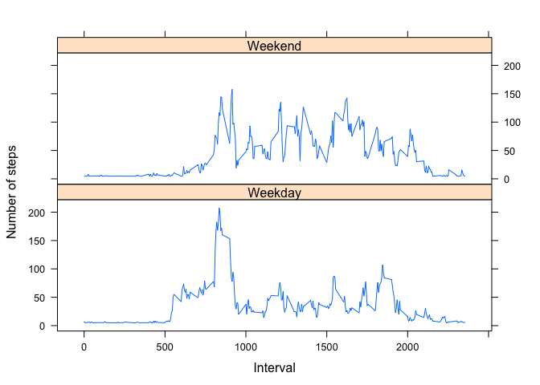

```r
averagedActivity_new <- aggregate(steps ~ interval + dayType, data=activity_new, mean)
names(averagedActivity_new) <- c("interval", "dayType", "steps")

xyplot(steps ~ interval | dayType, averagedActivity_new, type = "l", layout = c(1, 2),
    xlab = "Interval", ylab = "Number of steps")
```

```r
# Clear the workspace
rm(list = ls(all = TRUE))
```